# Risk Factor Analysis

## Outcome Variable

**Outcome Variable:** ever_co

## Predictor Variables

**Intervention Variable:** brthmon

**Adjustment Set:**

unadjusted

## Stratifying Variables

The analysis was stratified on these variable(s):

- agecat
- studyid
- country

## Data Summary

| agecat | studyid | country | brthmon | ever_co | n_cell | n |
| --- | --- | --- | --- | --- | --- | --- |
| 0-24 months | CMC-V-BCS-2002 | INDIA | 1 | 0 | 28 | 373 |
| 0-24 months | CMC-V-BCS-2002 | INDIA | 1 | 1 | 6 | 373 |
| 0-24 months | CMC-V-BCS-2002 | INDIA | 2 | 0 | 11 | 373 |
| 0-24 months | CMC-V-BCS-2002 | INDIA | 2 | 1 | 5 | 373 |
| 0-24 months | CMC-V-BCS-2002 | INDIA | 3 | 0 | 26 | 373 |
| 0-24 months | CMC-V-BCS-2002 | INDIA | 3 | 1 | 5 | 373 |
| 0-24 months | CMC-V-BCS-2002 | INDIA | 4 | 0 | 34 | 373 |
| 0-24 months | CMC-V-BCS-2002 | INDIA | 4 | 1 | 10 | 373 |
| 0-24 months | CMC-V-BCS-2002 | INDIA | 5 | 0 | 30 | 373 |
| 0-24 months | CMC-V-BCS-2002 | INDIA | 5 | 1 | 6 | 373 |
| 0-24 months | CMC-V-BCS-2002 | INDIA | 6 | 0 | 30 | 373 |
| 0-24 months | CMC-V-BCS-2002 | INDIA | 6 | 1 | 7 | 373 |
| 0-24 months | CMC-V-BCS-2002 | INDIA | 7 | 0 | 31 | 373 |
| 0-24 months | CMC-V-BCS-2002 | INDIA | 7 | 1 | 8 | 373 |
| 0-24 months | CMC-V-BCS-2002 | INDIA | 8 | 0 | 14 | 373 |
| 0-24 months | CMC-V-BCS-2002 | INDIA | 8 | 1 | 4 | 373 |
| 0-24 months | CMC-V-BCS-2002 | INDIA | 9 | 0 | 16 | 373 |
| 0-24 months | CMC-V-BCS-2002 | INDIA | 9 | 1 | 5 | 373 |
| 0-24 months | CMC-V-BCS-2002 | INDIA | 10 | 0 | 22 | 373 |
| 0-24 months | CMC-V-BCS-2002 | INDIA | 10 | 1 | 7 | 373 |
| 0-24 months | CMC-V-BCS-2002 | INDIA | 11 | 0 | 31 | 373 |
| 0-24 months | CMC-V-BCS-2002 | INDIA | 11 | 1 | 12 | 373 |
| 0-24 months | CMC-V-BCS-2002 | INDIA | 12 | 0 | 14 | 373 |
| 0-24 months | CMC-V-BCS-2002 | INDIA | 12 | 1 | 11 | 373 |
| 0-24 months | CMIN | BANGLADESH | 1 | 0 | 20 | 271 |
| 0-24 months | CMIN | BANGLADESH | 1 | 1 | 8 | 271 |
| 0-24 months | CMIN | BANGLADESH | 2 | 0 | 20 | 271 |
| 0-24 months | CMIN | BANGLADESH | 2 | 1 | 7 | 271 |
| 0-24 months | CMIN | BANGLADESH | 3 | 0 | 14 | 271 |
| 0-24 months | CMIN | BANGLADESH | 3 | 1 | 6 | 271 |

[output cut: 1746 more lines]

The following strata were considered:

- agecat: 0-24 months, studyid: CMC-V-BCS-2002, country: INDIA
- agecat: 0-24 months, studyid: CMIN, country: BANGLADESH
- agecat: 0-24 months, studyid: CONTENT, country: PERU
- agecat: 0-24 months, studyid: EE, country: PAKISTAN
- agecat: 0-24 months, studyid: GMS-Nepal, country: NEPAL
- agecat: 0-24 months, studyid: Guatemala BSC, country: GUATEMALA
- agecat: 0-24 months, studyid: iLiNS-Zinc, country: BURKINA FASO
- agecat: 0-24 months, studyid: IRC, country: INDIA
- agecat: 0-24 months, studyid: Keneba, country: GAMBIA
- agecat: 0-24 months, studyid: LCNI-5, country: MALAWI
- agecat: 0-24 months, studyid: MAL-ED, country: BANGLADESH
- agecat: 0-24 months, studyid: MAL-ED, country: BRAZIL
- agecat: 0-24 months, studyid: MAL-ED, country: INDIA
- agecat: 0-24 months, studyid: MAL-ED, country: NEPAL
- agecat: 0-24 months, studyid: MAL-ED, country: PERU
- agecat: 0-24 months, studyid: MAL-ED, country: SOUTH AFRICA
- agecat: 0-24 months, studyid: MAL-ED, country: TANZANIA, UNITED REPUBLIC OF
- agecat: 0-24 months, studyid: NIH-Birth, country: BANGLADESH
- agecat: 0-24 months, studyid: PROBIT, country: BELARUS
- agecat: 0-24 months, studyid: PROVIDE, country: BANGLADESH
- agecat: 0-24 months, studyid: ResPak, country: PAKISTAN
- agecat: 0-24 months, studyid: SAS-CompFeed, country: INDIA
- agecat: 0-24 months, studyid: SAS-FoodSuppl, country: INDIA
- agecat: 0-24 months, studyid: TanzaniaChild2, country: TANZANIA, UNITED REPUBLIC OF
- agecat: 0-24 months, studyid: ZVITAMBO, country: ZIMBABWE
- agecat: 0-6 months, studyid: CMC-V-BCS-2002, country: INDIA
- agecat: 0-6 months, studyid: CMIN, country: BANGLADESH
- agecat: 0-6 months, studyid: CONTENT, country: PERU
- agecat: 0-6 months, studyid: EE, country: PAKISTAN
- agecat: 0-6 months, studyid: GMS-Nepal, country: NEPAL
- agecat: 0-6 months, studyid: Guatemala BSC, country: GUATEMALA
- agecat: 0-6 months, studyid: IRC, country: INDIA
- agecat: 0-6 months, studyid: Keneba, country: GAMBIA
- agecat: 0-6 months, studyid: LCNI-5, country: MALAWI
- agecat: 0-6 months, studyid: MAL-ED, country: BANGLADESH
- agecat: 0-6 months, studyid: MAL-ED, country: BRAZIL
- agecat: 0-6 months, studyid: MAL-ED, country: INDIA
- agecat: 0-6 months, studyid: MAL-ED, country: NEPAL
- agecat: 0-6 months, studyid: MAL-ED, country: PERU
- agecat: 0-6 months, studyid: MAL-ED, country: SOUTH AFRICA
- agecat: 0-6 months, studyid: MAL-ED, country: TANZANIA, UNITED REPUBLIC OF
- agecat: 0-6 months, studyid: NIH-Birth, country: BANGLADESH
- agecat: 0-6 months, studyid: PROBIT, country: BELARUS
- agecat: 0-6 months, studyid: PROVIDE, country: BANGLADESH
- agecat: 0-6 months, studyid: ResPak, country: PAKISTAN
- agecat: 0-6 months, studyid: SAS-CompFeed, country: INDIA
- agecat: 0-6 months, studyid: SAS-FoodSuppl, country: INDIA
- agecat: 0-6 months, studyid: TanzaniaChild2, country: TANZANIA, UNITED REPUBLIC OF
- agecat: 0-6 months, studyid: ZVITAMBO, country: ZIMBABWE
- agecat: 6-24 months, studyid: CMC-V-BCS-2002, country: INDIA
- agecat: 6-24 months, studyid: CMIN, country: BANGLADESH
- agecat: 6-24 months, studyid: CONTENT, country: PERU
- agecat: 6-24 months, studyid: EE, country: PAKISTAN
- agecat: 6-24 months, studyid: GMS-Nepal, country: NEPAL
- agecat: 6-24 months, studyid: Guatemala BSC, country: GUATEMALA
- agecat: 6-24 months, studyid: iLiNS-Zinc, country: BURKINA FASO
- agecat: 6-24 months, studyid: IRC, country: INDIA
- agecat: 6-24 months, studyid: Keneba, country: GAMBIA
- agecat: 6-24 months, studyid: LCNI-5, country: MALAWI
- agecat: 6-24 months, studyid: MAL-ED, country: BANGLADESH
- agecat: 6-24 months, studyid: MAL-ED, country: BRAZIL
- agecat: 6-24 months, studyid: MAL-ED, country: INDIA
- agecat: 6-24 months, studyid: MAL-ED, country: NEPAL
- agecat: 6-24 months, studyid: MAL-ED, country: PERU
- agecat: 6-24 months, studyid: MAL-ED, country: SOUTH AFRICA
- agecat: 6-24 months, studyid: MAL-ED, country: TANZANIA, UNITED REPUBLIC OF
- agecat: 6-24 months, studyid: NIH-Birth, country: BANGLADESH
- agecat: 6-24 months, studyid: PROBIT, country: BELARUS
- agecat: 6-24 months, studyid: PROVIDE, country: BANGLADESH
- agecat: 6-24 months, studyid: ResPak, country: PAKISTAN
- agecat: 6-24 months, studyid: SAS-CompFeed, country: INDIA
- agecat: 6-24 months, studyid: SAS-FoodSuppl, country: INDIA
- agecat: 6-24 months, studyid: TanzaniaChild2, country: TANZANIA, UNITED REPUBLIC OF
- agecat: 6-24 months, studyid: ZVITAMBO, country: ZIMBABWE

### Dropped Strata

Some strata were dropped due to rare outcomes:

- agecat: 0-24 months, studyid: CMC-V-BCS-2002, country: INDIA
- agecat: 0-24 months, studyid: CMIN, country: BANGLADESH
- agecat: 0-24 months, studyid: CONTENT, country: PERU
- agecat: 0-24 months, studyid: EE, country: PAKISTAN
- agecat: 0-24 months, studyid: GMS-Nepal, country: NEPAL
- agecat: 0-24 months, studyid: Guatemala BSC, country: GUATEMALA
- agecat: 0-24 months, studyid: IRC, country: INDIA
- agecat: 0-24 months, studyid: LCNI-5, country: MALAWI
- agecat: 0-24 months, studyid: MAL-ED, country: BANGLADESH
- agecat: 0-24 months, studyid: MAL-ED, country: BRAZIL
- agecat: 0-24 months, studyid: MAL-ED, country: INDIA
- agecat: 0-24 months, studyid: MAL-ED, country: NEPAL
- agecat: 0-24 months, studyid: MAL-ED, country: PERU
- agecat: 0-24 months, studyid: MAL-ED, country: SOUTH AFRICA
- agecat: 0-24 months, studyid: MAL-ED, country: TANZANIA, UNITED REPUBLIC OF
- agecat: 0-24 months, studyid: PROBIT, country: BELARUS
- agecat: 0-24 months, studyid: PROVIDE, country: BANGLADESH
- agecat: 0-24 months, studyid: ResPak, country: PAKISTAN
- agecat: 0-24 months, studyid: SAS-FoodSuppl, country: INDIA
- agecat: 0-6 months, studyid: CMC-V-BCS-2002, country: INDIA
- agecat: 0-6 months, studyid: CMIN, country: BANGLADESH
- agecat: 0-6 months, studyid: CONTENT, country: PERU
- agecat: 0-6 months, studyid: EE, country: PAKISTAN
- agecat: 0-6 months, studyid: GMS-Nepal, country: NEPAL
- agecat: 0-6 months, studyid: Guatemala BSC, country: GUATEMALA
- agecat: 0-6 months, studyid: IRC, country: INDIA
- agecat: 0-6 months, studyid: Keneba, country: GAMBIA
- agecat: 0-6 months, studyid: LCNI-5, country: MALAWI
- agecat: 0-6 months, studyid: MAL-ED, country: BANGLADESH
- agecat: 0-6 months, studyid: MAL-ED, country: BRAZIL
- agecat: 0-6 months, studyid: MAL-ED, country: INDIA
- agecat: 0-6 months, studyid: MAL-ED, country: NEPAL
- agecat: 0-6 months, studyid: MAL-ED, country: PERU
- agecat: 0-6 months, studyid: MAL-ED, country: SOUTH AFRICA
- agecat: 0-6 months, studyid: MAL-ED, country: TANZANIA, UNITED REPUBLIC OF
- agecat: 0-6 months, studyid: NIH-Birth, country: BANGLADESH
- agecat: 0-6 months, studyid: PROBIT, country: BELARUS
- agecat: 0-6 months, studyid: PROVIDE, country: BANGLADESH
- agecat: 0-6 months, studyid: ResPak, country: PAKISTAN
- agecat: 0-6 months, studyid: SAS-FoodSuppl, country: INDIA
- agecat: 0-6 months, studyid: TanzaniaChild2, country: TANZANIA, UNITED REPUBLIC OF
- agecat: 6-24 months, studyid: CMC-V-BCS-2002, country: INDIA
- agecat: 6-24 months, studyid: CMIN, country: BANGLADESH
- agecat: 6-24 months, studyid: CONTENT, country: PERU
- agecat: 6-24 months, studyid: EE, country: PAKISTAN
- agecat: 6-24 months, studyid: GMS-Nepal, country: NEPAL
- agecat: 6-24 months, studyid: Guatemala BSC, country: GUATEMALA
- agecat: 6-24 months, studyid: IRC, country: INDIA
- agecat: 6-24 months, studyid: LCNI-5, country: MALAWI
- agecat: 6-24 months, studyid: MAL-ED, country: BANGLADESH
- agecat: 6-24 months, studyid: MAL-ED, country: BRAZIL
- agecat: 6-24 months, studyid: MAL-ED, country: INDIA
- agecat: 6-24 months, studyid: MAL-ED, country: NEPAL
- agecat: 6-24 months, studyid: MAL-ED, country: PERU
- agecat: 6-24 months, studyid: MAL-ED, country: SOUTH AFRICA
- agecat: 6-24 months, studyid: MAL-ED, country: TANZANIA, UNITED REPUBLIC OF
- agecat: 6-24 months, studyid: PROBIT, country: BELARUS
- agecat: 6-24 months, studyid: PROVIDE, country: BANGLADESH
- agecat: 6-24 months, studyid: ResPak, country: PAKISTAN
- agecat: 6-24 months, studyid: SAS-FoodSuppl, country: INDIA

## Methods Detail

We’re interested in the causal parameters $E[Y_a]$ for all values of $a \in \mathcal{A}$. These parameters represent the mean outcome if, possibly contrary to fact, we intervened to set all units to have $A=a$. Under the randomization and positivity assumptions, these are identified by the statistical parameters $\psi_a=E_W[E_{Y|A,W}(Y|A=a,W)]$. In addition, we’re interested in the mean of $Y$, $E[Y]$ under no intervention (the observed mean). We will estimate these parameters by using SuperLearner to fit the relevant likelihood factors – $E_{Y|A,W}(Y|A=a,W)$ and $p(A=a|W)$, and then updating our likelihood fit using a joint TMLE.

For unadjusted analyses ($W=\{\}$), initial likelihoods were estimated using Lrnr_glm to estimate the simple $E(Y|A)$ and Lrnr_mean to estimate $p(A)$. For adjusted analyses, a small library containing Lrnr_glmnet, Lrnr_xgboost, and Lrnr_mean was used.

Having estimated these parameters, we will then use the delta method to estimate relative risks and attributable risks relative to a prespecified baseline level of $A$.

# Results Detail

## Results Plots

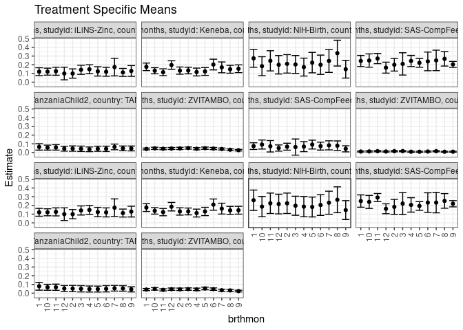

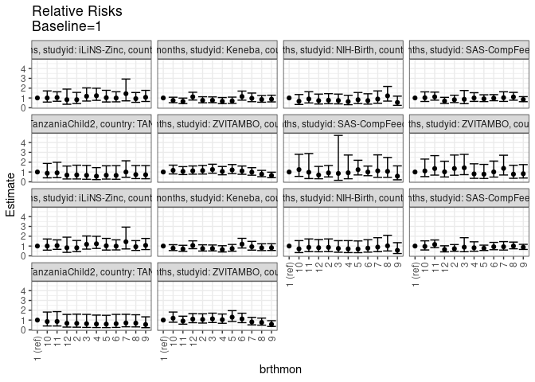

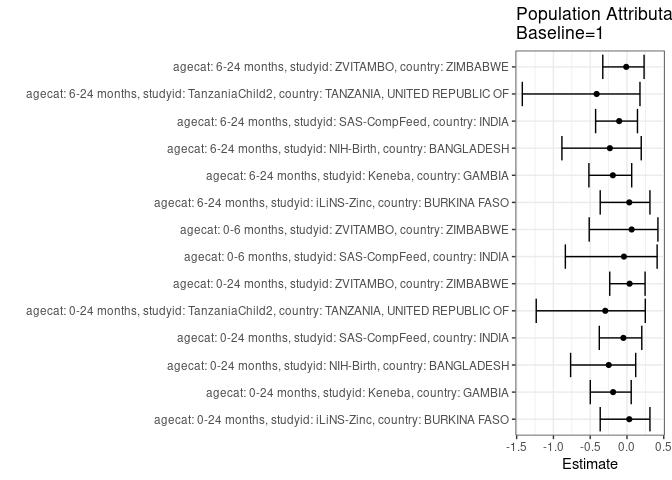

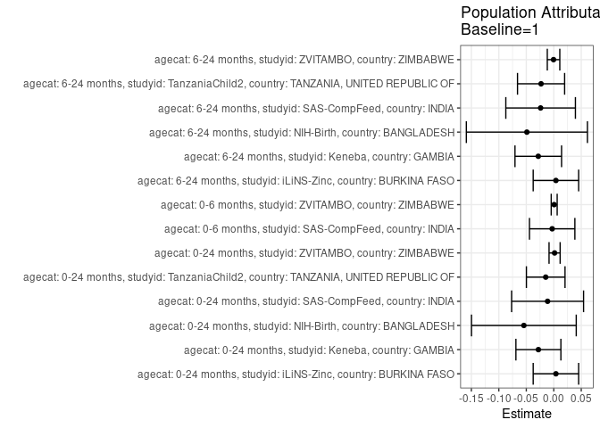

## Results Table

### Parameter: TSM

| agecat | studyid | country | intervention_level | baseline_level | estimate | ci_lower | ci_upper |
| --- | --- | --- | --- | --- | --- | --- | --- |
| 0-24 months | iLiNS-Zinc | BURKINA FASO | 1 | NA | 0.1207430 | 0.0755590 | 0.1659270 |
| 0-24 months | iLiNS-Zinc | BURKINA FASO | 2 | NA | 0.0994475 | 0.0460298 | 0.1528652 |
| 0-24 months | iLiNS-Zinc | BURKINA FASO | 3 | NA | 0.1421320 | 0.0898603 | 0.1944037 |
| 0-24 months | iLiNS-Zinc | BURKINA FASO | 4 | NA | 0.1483254 | 0.0969427 | 0.1997080 |
| 0-24 months | iLiNS-Zinc | BURKINA FASO | 5 | NA | 0.1238532 | 0.0702933 | 0.1774131 |
| 0-24 months | iLiNS-Zinc | BURKINA FASO | 6 | NA | 0.1197917 | 0.0680619 | 0.1715214 |
| 0-24 months | iLiNS-Zinc | BURKINA FASO | 7 | NA | 0.1734694 | 0.0721277 | 0.2748111 |
| 0-24 months | iLiNS-Zinc | BURKINA FASO | 8 | NA | 0.1122112 | 0.0665272 | 0.1578952 |
| 0-24 months | iLiNS-Zinc | BURKINA FASO | 9 | NA | 0.1289538 | 0.0672907 | 0.1906168 |
| 0-24 months | iLiNS-Zinc | BURKINA FASO | 10 | NA | 0.1209677 | 0.0808314 | 0.1611040 |
| 0-24 months | iLiNS-Zinc | BURKINA FASO | 11 | NA | 0.1257310 | 0.0795208 | 0.1719412 |
| 0-24 months | iLiNS-Zinc | BURKINA FASO | 12 | NA | 0.0996885 | 0.0270477 | 0.1723293 |
| 0-24 months | Keneba | GAMBIA | 1 | NA | 0.1762712 | 0.1327807 | 0.2197617 |
| 0-24 months | Keneba | GAMBIA | 2 | NA | 0.1328125 | 0.0912331 | 0.1743919 |
| 0-24 months | Keneba | GAMBIA | 3 | NA | 0.1339869 | 0.0958140 | 0.1721598 |
| 0-24 months | Keneba | GAMBIA | 4 | NA | 0.1167513 | 0.0719013 | 0.1616012 |
| 0-24 months | Keneba | GAMBIA | 5 | NA | 0.1231527 | 0.0779402 | 0.1683652 |
| 0-24 months | Keneba | GAMBIA | 6 | NA | 0.2024540 | 0.1407562 | 0.2641518 |
| 0-24 months | Keneba | GAMBIA | 7 | NA | 0.1702128 | 0.1081698 | 0.2322557 |
| 0-24 months | Keneba | GAMBIA | 8 | NA | 0.1483051 | 0.1029541 | 0.1936561 |
| 0-24 months | Keneba | GAMBIA | 9 | NA | 0.1541502 | 0.1096480 | 0.1986524 |
| 0-24 months | Keneba | GAMBIA | 10 | NA | 0.1314286 | 0.0960259 | 0.1668313 |
| 0-24 months | Keneba | GAMBIA | 11 | NA | 0.1141732 | 0.0750565 | 0.1532899 |
| 0-24 months | Keneba | GAMBIA | 12 | NA | 0.1969112 | 0.1484728 | 0.2453496 |
| 0-24 months | NIH-Birth | BANGLADESH | 1 | NA | 0.2739726 | 0.1715808 | 0.3763644 |
| 0-24 months | NIH-Birth | BANGLADESH | 2 | NA | 0.2105263 | 0.1046056 | 0.3164470 |
| 0-24 months | NIH-Birth | BANGLADESH | 3 | NA | 0.2033898 | 0.1005982 | 0.3061815 |
| 0-24 months | NIH-Birth | BANGLADESH | 4 | NA | 0.1730769 | 0.0701695 | 0.2759844 |
| 0-24 months | NIH-Birth | BANGLADESH | 5 | NA | 0.2244898 | 0.1075694 | 0.3414102 |
| 0-24 months | NIH-Birth | BANGLADESH | 6 | NA | 0.2000000 | 0.0890387 | 0.3109613 |

[output cut: 138 more lines]

### Parameter: E(Y)

| agecat | studyid | country | intervention_level | baseline_level | estimate | ci_lower | ci_upper |
| --- | --- | --- | --- | --- | --- | --- | --- |
| 0-24 months | iLiNS-Zinc | BURKINA FASO | NA | NA | 0.1246554 | 0.1041227 | 0.1451882 |
| 0-24 months | Keneba | GAMBIA | NA | NA | 0.1483007 | 0.1353925 | 0.1612090 |
| 0-24 months | NIH-Birth | BANGLADESH | NA | NA | 0.2195513 | 0.1870467 | 0.2520558 |
| 0-24 months | SAS-CompFeed | INDIA | NA | NA | 0.2319894 | 0.1917264 | 0.2722524 |
| 0-24 months | TanzaniaChild2 | TANZANIA, UNITED REPUBLIC OF | NA | NA | 0.0496661 | 0.0409652 | 0.0583670 |
| 0-24 months | ZVITAMBO | ZIMBABWE | NA | NA | 0.0423899 | 0.0390454 | 0.0457344 |
| 0-6 months | SAS-CompFeed | INDIA | NA | NA | 0.0704787 | 0.0478990 | 0.0930584 |
| 0-6 months | ZVITAMBO | ZIMBABWE | NA | NA | 0.0120612 | 0.0102430 | 0.0138795 |
| 6-24 months | iLiNS-Zinc | BURKINA FASO | NA | NA | 0.1246554 | 0.1041227 | 0.1451882 |
| 6-24 months | Keneba | GAMBIA | NA | NA | 0.1469835 | 0.1337108 | 0.1602563 |
| 6-24 months | NIH-Birth | BANGLADESH | NA | NA | 0.2103321 | 0.1759902 | 0.2446740 |
| 6-24 months | SAS-CompFeed | INDIA | NA | NA | 0.2260619 | 0.1909133 | 0.2612105 |
| 6-24 months | TanzaniaChild2 | TANZANIA, UNITED REPUBLIC OF | NA | NA | 0.0560238 | 0.0459853 | 0.0660623 |
| 6-24 months | ZVITAMBO | ZIMBABWE | NA | NA | 0.0410617 | 0.0373214 | 0.0448020 |

### Parameter: RR

| agecat | studyid | country | intervention_level | baseline_level | estimate | ci_lower | ci_upper |
| --- | --- | --- | --- | --- | --- | --- | --- |
| 0-24 months | iLiNS-Zinc | BURKINA FASO | 1 | 1 | 1.0000000 | 1.0000000 | 1.0000000 |
| 0-24 months | iLiNS-Zinc | BURKINA FASO | 2 | 1 | 0.8236294 | 0.4328209 | 1.5673120 |
| 0-24 months | iLiNS-Zinc | BURKINA FASO | 3 | 1 | 1.1771443 | 0.6849525 | 2.0230146 |
| 0-24 months | iLiNS-Zinc | BURKINA FASO | 4 | 1 | 1.2284382 | 0.7569584 | 1.9935844 |
| 0-24 months | iLiNS-Zinc | BURKINA FASO | 5 | 1 | 1.0257586 | 0.5915597 | 1.7786552 |
| 0-24 months | iLiNS-Zinc | BURKINA FASO | 6 | 1 | 0.9921207 | 0.6037119 | 1.6304192 |
| 0-24 months | iLiNS-Zinc | BURKINA FASO | 7 | 1 | 1.4366824 | 0.7045404 | 2.9296493 |
| 0-24 months | iLiNS-Zinc | BURKINA FASO | 8 | 1 | 0.9293391 | 0.5564906 | 1.5519959 |
| 0-24 months | iLiNS-Zinc | BURKINA FASO | 9 | 1 | 1.0680017 | 0.6432044 | 1.7733519 |
| 0-24 months | iLiNS-Zinc | BURKINA FASO | 10 | 1 | 1.0018610 | 0.5840736 | 1.7184916 |
| 0-24 months | iLiNS-Zinc | BURKINA FASO | 11 | 1 | 1.0413105 | 0.6657247 | 1.6287930 |
| 0-24 months | iLiNS-Zinc | BURKINA FASO | 12 | 1 | 0.8256250 | 0.3585655 | 1.9010662 |
| 0-24 months | Keneba | GAMBIA | 1 | 1 | 1.0000000 | 1.0000000 | 1.0000000 |
| 0-24 months | Keneba | GAMBIA | 2 | 1 | 0.7534555 | 0.5057618 | 1.1224557 |
| 0-24 months | Keneba | GAMBIA | 3 | 1 | 0.7601181 | 0.5214378 | 1.1080508 |
| 0-24 months | Keneba | GAMBIA | 4 | 1 | 0.6623389 | 0.4195659 | 1.0455874 |
| 0-24 months | Keneba | GAMBIA | 5 | 1 | 0.6986548 | 0.4489127 | 1.0873351 |
| 0-24 months | Keneba | GAMBIA | 6 | 1 | 1.1485370 | 0.7759903 | 1.6999404 |
| 0-24 months | Keneba | GAMBIA | 7 | 1 | 0.9656301 | 0.6218054 | 1.4995712 |
| 0-24 months | Keneba | GAMBIA | 8 | 1 | 0.8413462 | 0.5679799 | 1.2462824 |
| 0-24 months | Keneba | GAMBIA | 9 | 1 | 0.8745059 | 0.5981848 | 1.2784688 |
| 0-24 months | Keneba | GAMBIA | 10 | 1 | 0.7456044 | 0.5174490 | 1.0743588 |
| 0-24 months | Keneba | GAMBIA | 11 | 1 | 0.6477135 | 0.4246424 | 0.9879673 |
| 0-24 months | Keneba | GAMBIA | 12 | 1 | 1.1170924 | 0.7884597 | 1.5827003 |
| 0-24 months | NIH-Birth | BANGLADESH | 1 | 1 | 1.0000000 | 1.0000000 | 1.0000000 |
| 0-24 months | NIH-Birth | BANGLADESH | 2 | 1 | 0.7684211 | 0.4105897 | 1.4381045 |
| 0-24 months | NIH-Birth | BANGLADESH | 3 | 1 | 0.7423729 | 0.3959490 | 1.3918901 |
| 0-24 months | NIH-Birth | BANGLADESH | 4 | 1 | 0.6317308 | 0.3129942 | 1.2750515 |
| 0-24 months | NIH-Birth | BANGLADESH | 5 | 1 | 0.8193878 | 0.4316069 | 1.5555737 |
| 0-24 months | NIH-Birth | BANGLADESH | 6 | 1 | 0.7300000 | 0.3739425 | 1.4250854 |

[output cut: 138 more lines]

### Parameter: PAR

| agecat | studyid | country | intervention_level | baseline_level | estimate | ci_lower | ci_upper |
| --- | --- | --- | --- | --- | --- | --- | --- |
| 0-24 months | iLiNS-Zinc | BURKINA FASO | 1 | NA | 0.0039124 | -0.0374485 | 0.0452733 |
| 0-24 months | Keneba | GAMBIA | 1 | NA | -0.0279705 | -0.0688967 | 0.0129558 |
| 0-24 months | NIH-Birth | BANGLADESH | 1 | NA | -0.0544213 | -0.1497503 | 0.0409077 |
| 0-24 months | SAS-CompFeed | INDIA | 1 | NA | -0.0112538 | -0.0767405 | 0.0542329 |
| 0-24 months | TanzaniaChild2 | TANZANIA, UNITED REPUBLIC OF | 1 | NA | -0.0146614 | -0.0498086 | 0.0204858 |
| 0-24 months | ZVITAMBO | ZIMBABWE | 1 | NA | 0.0014977 | -0.0085818 | 0.0115772 |
| 0-6 months | SAS-CompFeed | INDIA | 1 | NA | -0.0029158 | -0.0442420 | 0.0384104 |
| 0-6 months | ZVITAMBO | ZIMBABWE | 1 | NA | 0.0007661 | -0.0046575 | 0.0061897 |
| 6-24 months | iLiNS-Zinc | BURKINA FASO | 1 | NA | 0.0039124 | -0.0374485 | 0.0452733 |
| 6-24 months | Keneba | GAMBIA | 1 | NA | -0.0281989 | -0.0705858 | 0.0141880 |
| 6-24 months | NIH-Birth | BANGLADESH | 1 | NA | -0.0489272 | -0.1591042 | 0.0612499 |
| 6-24 months | SAS-CompFeed | INDIA | 1 | NA | -0.0239381 | -0.0872763 | 0.0394001 |
| 6-24 months | TanzaniaChild2 | TANZANIA, UNITED REPUBLIC OF | 1 | NA | -0.0231129 | -0.0659851 | 0.0197593 |
| 6-24 months | ZVITAMBO | ZIMBABWE | 1 | NA | -0.0004086 | -0.0117962 | 0.0109790 |

### Parameter: PAF

| agecat | studyid | country | intervention_level | baseline_level | estimate | ci_lower | ci_upper |
| --- | --- | --- | --- | --- | --- | --- | --- |
| 0-24 months | iLiNS-Zinc | BURKINA FASO | 1 | NA | 0.0313857 | -0.3639986 | 0.3121594 |
| 0-24 months | Keneba | GAMBIA | 1 | NA | -0.1886064 | -0.4988803 | 0.0574396 |
| 0-24 months | NIH-Birth | BANGLADESH | 1 | NA | -0.2478752 | -0.7665396 | 0.1185069 |
| 0-24 months | SAS-CompFeed | INDIA | 1 | NA | -0.0485100 | -0.3764055 | 0.2012722 |
| 0-24 months | TanzaniaChild2 | TANZANIA, UNITED REPUBLIC OF | 1 | NA | -0.2951988 | -1.2339700 | 0.2490768 |
| 0-24 months | ZVITAMBO | ZIMBABWE | 1 | NA | 0.0353317 | -0.2342979 | 0.2460614 |
| 0-6 months | SAS-CompFeed | INDIA | 1 | NA | -0.0413710 | -0.8379265 | 0.4099582 |
| 0-6 months | ZVITAMBO | ZIMBABWE | 1 | NA | 0.0635145 | -0.5135259 | 0.4205550 |
| 6-24 months | iLiNS-Zinc | BURKINA FASO | 1 | NA | 0.0313857 | -0.3639986 | 0.3121594 |
| 6-24 months | Keneba | GAMBIA | 1 | NA | -0.1918510 | -0.5177192 | 0.0640504 |
| 6-24 months | NIH-Birth | BANGLADESH | 1 | NA | -0.2326186 | -0.8846191 | 0.1938166 |
| 6-24 months | SAS-CompFeed | INDIA | 1 | NA | -0.1058917 | -0.4264502 | 0.1426294 |
| 6-24 months | TanzaniaChild2 | TANZANIA, UNITED REPUBLIC OF | 1 | NA | -0.4125549 | -1.4230836 | 0.1765404 |
| 6-24 months | ZVITAMBO | ZIMBABWE | 1 | NA | -0.0099515 | -0.3290943 | 0.2325586 |